# Homework #3

```r
data(tips, package = "reshape2") # Loading the data set.
```

### Question 1

```r
# How many parties did the waiter serve? Don't forget to store the number and print

#names(tips)

numParty <- sum(table(tips$size))
print(numParty)
```

```
## [1] 244
```

##### The waiter served 244 parties during the study.

### Question 2

```r
#What are the types of variables in the data frame?

str(tips)
```

```
## 'data.frame':    244 obs. of  7 variables:
##  $ total_bill: num  17 10.3 21 23.7 24.6 ...
##  $ tip       : num  1.01 1.66 3.5 3.31 3.61 4.71 2 3.12 1.96 3.23 ...
##  $ sex       : Factor w/ 2 levels "Female","Male": 1 2 2 2 1 2 2 2 2 2 ...
##  $ smoker    : Factor w/ 2 levels "No","Yes": 1 1 1 1 1 1 1 1 1 1 ...
##  $ day       : Factor w/ 4 levels "Fri","Sat","Sun",..: 3 3 3 3 3 3 3 3 3 3 ...
##  $ time      : Factor w/ 2 levels "Dinner","Lunch": 1 1 1 1 1 1 1 1 1 1 ...
##  $ size      : int  2 3 3 2 4 4 2 4 2 2 ...
```

```r
summary(tips)
```

```
##    total_bill         tip             sex      smoker      day
##  Min.   : 3.07   Min.   : 1.000   Female: 87   No :151   Fri :19
##  1st Qu.:13.35   1st Qu.: 2.000   Male  :157   Yes: 93   Sat :87
##  Median :17.80   Median : 2.900                          Sun :76
##  Mean   :19.79   Mean   : 2.998                          Thur:62
##  3rd Qu.:24.13   3rd Qu.: 3.562
##  Max.   :50.81   Max.   :10.000
##      time          size
##  Dinner:176   Min.   :1.00
##  Lunch : 68   1st Qu.:2.00
##               Median :2.00
##               Mean   :2.57
##               3rd Qu.:3.00
##               Max.   :6.00
```

##### There are a total of 7 variables: total_bill(Numeric), tip(Numeric), sex(Factor), smoker(Factor), day(Factor), time(Factor), and Size(Integer).

### Question 3

```r
tips$day <- levels(factor(tips$day, levels = c("Thur", "Fri", "Sat", "Sun"))) #Reordered the factor variable day
day <- tips$day #Store the vector to the variable name day
print(day) #Print the variable
```

```
##   [1] "Thur" "Fri"  "Sat"  "Sun"  "Thur" "Fri"  "Sat"  "Sun"  "Thur" "Fri"
##  [11] "Sat"  "Sun"  "Thur" "Fri"  "Sat"  "Sun"  "Thur" "Fri"  "Sat"  "Sun"
##  [21] "Thur" "Fri"  "Sat"  "Sun"  "Thur" "Fri"  "Sat"  "Sun"  "Thur" "Fri"
##  [31] "Sat"  "Sun"  "Thur" "Fri"  "Sat"  "Sun"  "Thur" "Fri"  "Sat"  "Sun"
##  [41] "Thur" "Fri"  "Sat"  "Sun"  "Thur" "Fri"  "Sat"  "Sun"  "Thur" "Fri"
##  [51] "Sat"  "Sun"  "Thur" "Fri"  "Sat"  "Sun"  "Thur" "Fri"  "Sat"  "Sun"
##  [61] "Thur" "Fri"  "Sat"  "Sun"  "Thur" "Fri"  "Sat"  "Sun"  "Thur" "Fri"
##  [71] "Sat"  "Sun"  "Thur" "Fri"  "Sat"  "Sun"  "Thur" "Fri"  "Sat"  "Sun"
##  [81] "Thur" "Fri"  "Sat"  "Sun"  "Thur" "Fri"  "Sat"  "Sun"  "Thur" "Fri"
##  [91] "Sat"  "Sun"  "Thur" "Fri"  "Sat"  "Sun"  "Thur" "Fri"  "Sat"  "Sun"
## [101] "Thur" "Fri"  "Sat"  "Sun"  "Thur" "Fri"  "Sat"  "Sun"  "Thur" "Fri"
## [111] "Sat"  "Sun"  "Thur" "Fri"  "Sat"  "Sun"  "Thur" "Fri"  "Sat"  "Sun"
## [121] "Thur" "Fri"  "Sat"  "Sun"  "Thur" "Fri"  "Sat"  "Sun"  "Thur" "Fri"
## [131] "Sat"  "Sun"  "Thur" "Fri"  "Sat"  "Sun"  "Thur" "Fri"  "Sat"  "Sun"
## [141] "Thur" "Fri"  "Sat"  "Sun"  "Thur" "Fri"  "Sat"  "Sun"  "Thur" "Fri"
## [151] "Sat"  "Sun"  "Thur" "Fri"  "Sat"  "Sun"  "Thur" "Fri"  "Sat"  "Sun"
## [161] "Thur" "Fri"  "Sat"  "Sun"  "Thur" "Fri"  "Sat"  "Sun"  "Thur" "Fri"
## [171] "Sat"  "Sun"  "Thur" "Fri"  "Sat"  "Sun"  "Thur" "Fri"  "Sat"  "Sun"
## [181] "Thur" "Fri"  "Sat"  "Sun"  "Thur" "Fri"  "Sat"  "Sun"  "Thur" "Fri"
## [191] "Sat"  "Sun"  "Thur" "Fri"  "Sat"  "Sun"  "Thur" "Fri"  "Sat"  "Sun"
## [201] "Thur" "Fri"  "Sat"  "Sun"  "Thur" "Fri"  "Sat"  "Sun"  "Thur" "Fri"
## [211] "Sat"  "Sun"  "Thur" "Fri"  "Sat"  "Sun"  "Thur" "Fri"  "Sat"  "Sun"
## [221] "Thur" "Fri"  "Sat"  "Sun"  "Thur" "Fri"  "Sat"  "Sun"  "Thur" "Fri"
## [231] "Sat"  "Sun"  "Thur" "Fri"  "Sat"  "Sun"  "Thur" "Fri"  "Sat"  "Sun"
## [241] "Thur" "Fri"  "Sat"  "Sun"
```

```r
head(tips, 20) #Checking to make sure the variable is ordered correctly in the dataframe
```

```
##    total_bill  tip    sex smoker  day   time size
## 1       16.99 1.01 Female     No Thur Dinner    2
## 2       10.34 1.66   Male     No  Fri Dinner    3
## 3       21.01 3.50   Male     No  Sat Dinner    3
## 4       23.68 3.31   Male     No  Sun Dinner    2
## 5       24.59 3.61 Female     No Thur Dinner    4
## 6       25.29 4.71   Male     No  Fri Dinner    4
## 7        8.77 2.00   Male     No  Sat Dinner    2
## 8       26.88 3.12   Male     No  Sun Dinner    4
## 9       15.04 1.96   Male     No Thur Dinner    2
## 10      14.78 3.23   Male     No  Fri Dinner    2
## 11      10.27 1.71   Male     No  Sat Dinner    2
## 12      35.26 5.00 Female     No  Sun Dinner    4
## 13      15.42 1.57   Male     No Thur Dinner    2
## 14      18.43 3.00   Male     No  Fri Dinner    4
## 15      14.83 3.02 Female     No  Sat Dinner    2
## 16      21.58 3.92   Male     No  Sun Dinner    2
## 17      10.33 1.67 Female     No Thur Dinner    3
## 18      16.29 3.71   Male     No  Fri Dinner    3
## 19      16.97 3.50 Female     No  Sat Dinner    3
## 20      20.65 3.35   Male     No  Sun Dinner    3
```

### Question 4

```r
female5 <- tips[tips$sex == "Female" & tips$size >= 5,] # Created a data frame with desired conditions using logical operators
print(female5)
```

```
##     total_bill  tip    sex smoker day   time size
## 126      29.80 4.20 Female     No Fri  Lunch    6
## 144      27.05 5.00 Female     No Sun  Lunch    6
## 156      29.85 5.14 Female     No Sun Dinner    5
```

### Question 5

```r
library(ggplot2)

cor(tips$tip, tips$total_bill)
```

```
## [1] 0.6757341
```

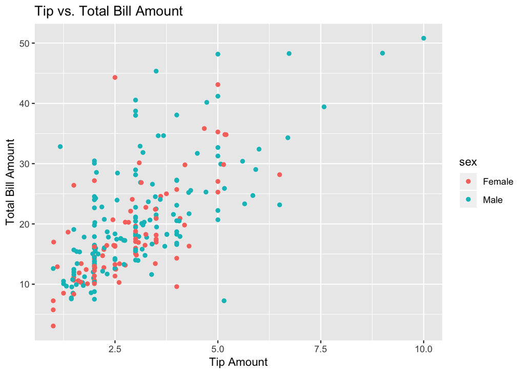

```r
ggplot(tips, aes(x = tip, y = total_bill, color = sex))+
  geom_point() + xlab("Tip Amount") + ylab("Total Bill Amount") + ggtitle("Tip vs. Total Bill Amount")
```

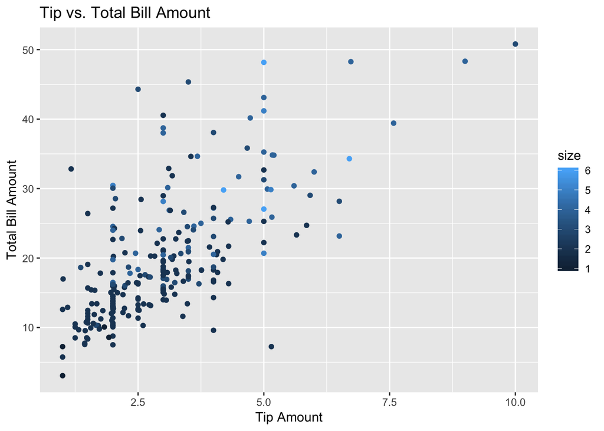

```r
ggplot(tips, aes(x = tip, y = total_bill, color = size))+
  geom_point() + xlab("Tip Amount") + ylab("Total Bill Amount") + ggtitle("Tip vs. Total Bill Amount")
```

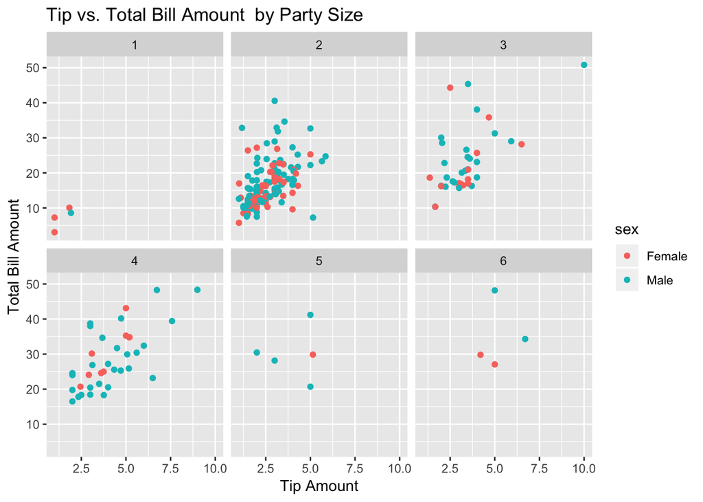

```r
ggplot(tips, aes(x = tip, y = total_bill, color = sex))+
  geom_point() + xlab("Tip Amount") + ylab("Total Bill Amount") + ggtitle("Tip vs. Total Bill Amount  by Party Size") +
  facet_wrap(~size, ncol = 3)
```

### Question 6

```r
#??tips

tips["tiprate"] <- NA

tips$tiprate = tips$tip / tips$total_bill

summary(tips$tiprate)
```

```
##    Min. 1st Qu.  Median    Mean 3rd Qu.    Max.
## 0.03564 0.12913 0.15477 0.16080 0.19148 0.71034
```

##### The average rate for tips is a 16%

### Question 7

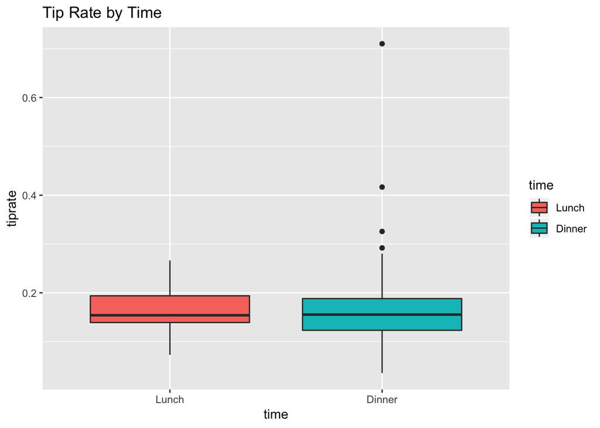

```r
tips$time <- factor(tips$time, levels = c("Lunch", "Dinner"))

ggplot(tips, aes(x = time, y = tiprate))+
  geom_boxplot(aes( fill = time)) + ggtitle("Tip Rate by Time")
```

### Question 8

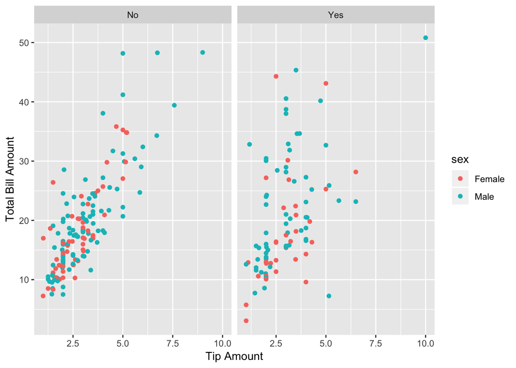

```r
femalesmokersTipper <- tips[tips$sex == "Female" & tips$smoker == 'Yes',]
malesmokersTipper <- tips[tips$sex == "Male" & tips$smoker == 'Yes',]

#summary(femalesmokersTipper)
#summary(malesmokersTipper)
#There are 33 Female Smokers
#There are 60 Male Smokers

ggplot(tips, aes(x = tip, total_bill, color = sex))+
  geom_point() + xlab("Tip Amount") + ylab("Total Bill Amount")+
  facet_wrap(~smoker)
```

##### Looking at the scatter plot comparing smokers and non-smokers, there seems to be a stronger linear relationship between tip and total_bill when the person who is paying does not smoke. There is a weak linear relationship between tip and total_bill when the customer that is paying also smokes. Both relationships are positive and have outliers. Looking at gender, males seem to be tipping more than females in general. Looking at the smokers that tipped, females seem to be more spread out and are easier to see. There are more nonsmokers that tip for both genders than smokers that tip.

### Question 9

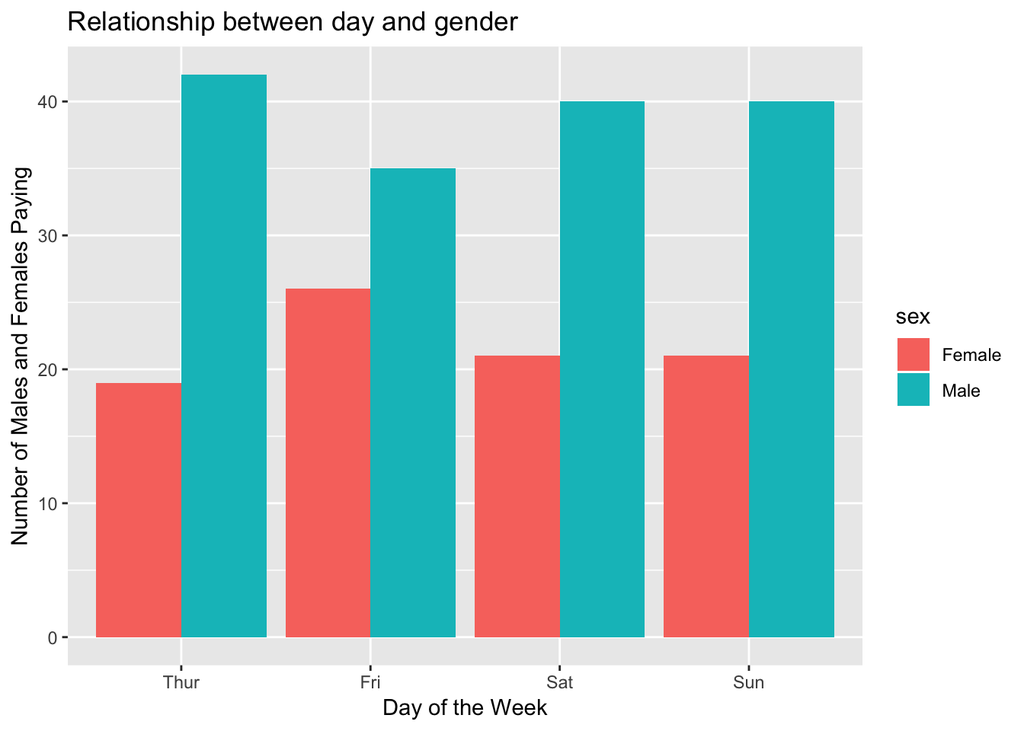

```r
tips$day <- factor(tips$day, levels = c("Thur", "Fri", "Sat", "Sun"))

ggplot(tips, aes(x = day))+
  geom_bar(aes(fill = sex), position = "dodge") + ggtitle("Relationship between day and gender") + ylab("Number of Males and Females Paying") + xlab("Day of the Week")
```

##### Looking at the bar graph we can see an interesting relationships. Overall male customers are tiping and paying more often than females every day of the week. Thursday seems to be the day where males pay the most amount of times, whle females pay the least amount of times. Friday seems to be the day where Males and Females are paying a similar amount of times, males are still paying more times than females. Saturday and Sunday seem to have the same distribution of amount of times male and female pay.